# Introduction to Probabilistic Programming

## Congressional Ideal Point Model

```python
df.head()
```

| rep | party | 0 | 1 | 2 | 3 | 4 | 5 | 6 | 7 | 8 | 9 | 10 | 11 | 12 | 13 | 14 | 15 |
| --- | --- | --- | --- | --- | --- | --- | --- | --- | --- | --- | --- | --- | --- | --- | --- | --- | --- |
| 0 | 0 | 0 | 1 | 0 | 1 | 1 | 1 | 0 | 0 | 0 | 1 | NaN | 1 | 1 | 1 | 0 | 1 |
| 1 | 0 | 0 | 1 | 0 | 1 | 1 | 1 | 0 | 0 | 0 | 0 | 0 | 1 | 1 | 1 | 0 | NaN |
| 2 | 1 | NaN | 1 | 1 | NaN | 1 | 1 | 0 | 0 | 0 | 0 | 1 | 0 | 1 | 1 | 0 | 0 |
| 3 | 1 | 0 | 1 | 1 | 0 | NaN | 1 | 0 | 0 | 0 | 0 | 1 | 0 | 1 | 0 | 0 | 1 |
| 4 | 1 | 1 | 1 | 1 | 0 | 1 | 1 | 0 | 0 | 0 | 0 | 1 | NaN | 1 | 1 | 1 | 1 |

```python
parties
```

```
Index(['republican', 'democrat'], dtype='object')
```

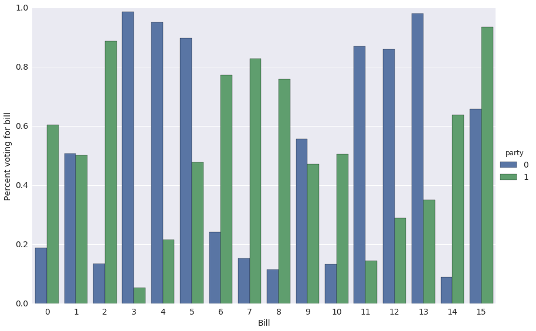

```python
grid.fig
```

$p_{i, j}$ is the probability that representative $i$ votes for bill $j$.

$$ \begin{align*} \log \left(\frac{p_{i, j}}{1 - p_{i, j}}\right) & = \gamma_j \left(\alpha_i - \beta_j\right) \\ & = \textrm{ability of bill } j \textrm{ to discriminate} \times (\textrm{conservativity of represetative } i\ - \textrm{conservativity of bill } j) \end{align*} $$

```python
with pm.Model() as ideal_point_model:
    # The conservativity of representative i
    alpha = pm.Normal('alpha', 0, 1., shape=N_REPS)

    # The conservativity of bill j
    mu_beta = pm.Normal('mu_beta', 0, 1e-3)
    sigma_beta = pm.Uniform('sigma_beta', 0, 1e2)
    beta = pm.Normal('beta', mu_beta, sd=sigma_beta, shape=N_BILLS)

    # The ability of bill j to discriminate
    mu_gamma = pm.Normal('mu_gamma', 0, 1e-3)
    sigma_gamma = pm.Uniform('sigma_gamma', 0, 1e2)
    gamma = pm.Normal('gamma', mu_gamma, sd=sigma_gamma, shape=N_BILLS)

    # The probability that representative i votes for bill j
    p = pm.Deterministic('p', T.nnet.sigmoid(gamma[vote_df.bill] * (alpha[vote_df.rep] - beta[vote_df.bill])))

    # The observed votes
    vote = pm.Bernoulli('vote', p, observed=vote_df.vote)
```

```
Applied interval-transform to sigma_beta and added transformed sigma_beta_interval to model.
Applied interval-transform to sigma_gamma and added transformed sigma_gamma_interval to model.
```

```python
samples = 20000
```

```python
with ideal_point_model:
    step = pm.Metropolis()
    ideal_point_trace = pm.sample(samples, step, random_seed=SEED)
```

```
 [-----------------100%-----------------] 20000 of 20000 complete in 107.5 sec
```

```python
rep_alpha = ideal_point_trace['alpha'].mean(axis=0)
```

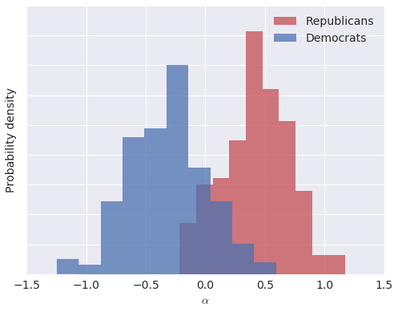

```python
fig
```

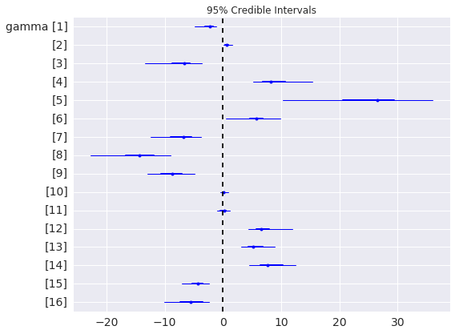

```python
pm.forestplot(ideal_point_trace, varnames=['gamma']);
```

[figure not shown]

Source: http://mqscores.berkeley.edu/

## Probabilistic Programming Ecosystem

| Probabilistic Programming System | Language | Discrete Variable Support | Automatic Differentiation/Hamiltonian Monte Carlo | Variational Inference |
| --- | --- | --- | --- | --- |
| [PyMC3](http://pymc-devs.github.io/pymc3/) | Python 2/3 |  |  |  |
| [PyMC2](http://pymc-devs.github.io/pymc/) | Python 2/3 |  |  |  |
| [Stan](http://mc-stan.org/) | C++, R, Python 2/3 |  |  |  |
| [BUGS](http://www.mrc-bsu.cam.ac.uk/software/bugs/) | Standalone program, R |  |  |  |
| JAGS | Standalone program, R |  |  |  |

## References

PyMC3 [examples repository](https://pymc-devs.github.io/pymc3/examples.html) ([regression](https://pymc-devs.github.io/pymc3/notebooks/GLM-linear.html), [matrix factorization](https://pymc-devs.github.io/pymc3/notebooks/pmf-pymc.html), [multilevel models](https://pymc-devs.github.io/pymc3/notebooks/rugby_analytics.html), [survival analysis](https://pymc-devs.github.io/pymc3/notebooks/survival_analysis.html), [Gaussian process smoothing](https://pymc-devs.github.io/pymc3/notebooks/GP-smoothing.html), [Dirichlet processes](https://pymc-devs.github.io/pymc3/notebooks/dp_mix.html)), [Bayesian neural nets](https://pymc-devs.github.io/pymc3/notebooks/bayesian_neural_network_advi.html))

[figure not shown]

[Probabilistic Programming and Bayesian Methods for Hackers](http://camdavidsonpilon.github.io/Probabilistic-Programming-and-Bayesian-Methods-for-Hackers/) (Open source, uses PyMC2, PyMC3 port [in progress](https://github.com/CamDavidsonPilon/Probabilistic-Programming-and-Bayesian-Methods-for-Hackers/pull/268))

[figure not shown]

[Think Bayes](http://www.greenteapress.com/thinkbayes/) (Available freely online, calculations in Python)

[figure not shown]

[Bayesian Data Analysis](http://www.stat.columbia.edu/~gelman/book/)

[figure not shown]

## Thank You!

The Jupyter notebook these slides were generated from is available [here](https://gist.github.com/AustinRochford/7e13346dd56853217cca48490da0dcbd)

[figure not shown]